# Comparing the miss-clarification rates of multiple machine learning models

Finn Massey

```r
# R Libraries
suppressMessages({
  library(tidyverse)
  library(glmnet)
  library(ranger)
  library(xgboost)
  library(ggplot2)
})
```

## Task 1 - Import the data

```r
# A)
set.seed(353)

# B)
bank.df = read.csv("bank_marketing.csv", sep=";")

# C)
discarded_variables = c('contact', 'day_of_week', 'month', 'duration')
```

I chose to discard the variables ‘contact’, ‘day_of_week’ and ‘month’ when if we want to build a model to predict y because I don’t believe there are any relevancy between the predictor and response variables. I think that the whether the contact communication type was a cell phone or a telephone won’t impact whether or not the user gets term deposit or not. While I do think that how long ago they were contacted might affect the response variable, bu the exact day of the week or month doesn’t help us because we are not provided with a year to give the month any context or a date (as there are multiple Tuesdays in the month e.g) for the day of the week. I also chose to discard ‘duration’ because in the variables descriptions it says “Thus, this input should only be included for benchmark purposes and should be discarded if the intention is to have a realistic predictive model.”. Since we are developing a realistic predictive model I chose to discard this variable as the it is impossible to know the duration of a call before a call and after the end of the call ‘y’ is know so this isn’t really relevant within a predictive model.

## Task 2 - Explore the data

```r
# A)
# Replacing y=yes with y=1 and y=no with y=0, and discarding all the variables from Task 1c.
bank.df = bank.df %>%
  select(-all_of(discarded_variables)) %>%
  mutate(y = ifelse(y == "yes", 1, 0))

# Splitting the data into training and testing data sets (90% & 10%).
indices = sample(nrow(bank.df), round(nrow(bank.df) * 0.1))
train.df = bank.df[-indices,]
test.df = bank.df[indices,]
```

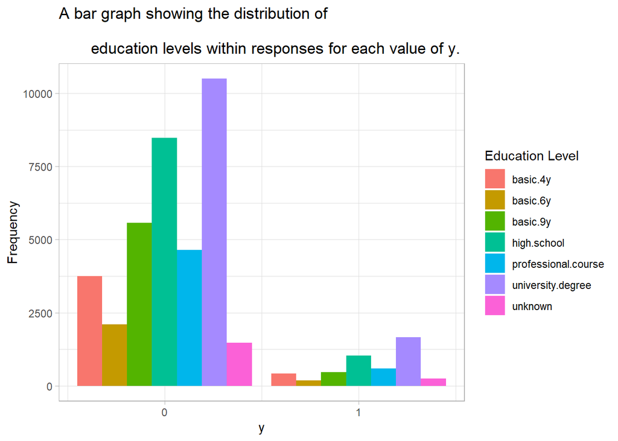

```r
# B)
# Bar Graph
ggplot(bank.df, aes(x=y, fill=education)) +
  geom_bar(position="dodge") +
  scale_x_continuous(breaks = c(0, 1), labels = c("0", "1")) +
  scale_fill_discrete(name = "Education Level") +
  xlab("y") +
  ylab("Frequency") +
  labs(title = "A bar graph showing the distribution of \n
       education levels within responses for each value of y.") +
  theme_light()
```

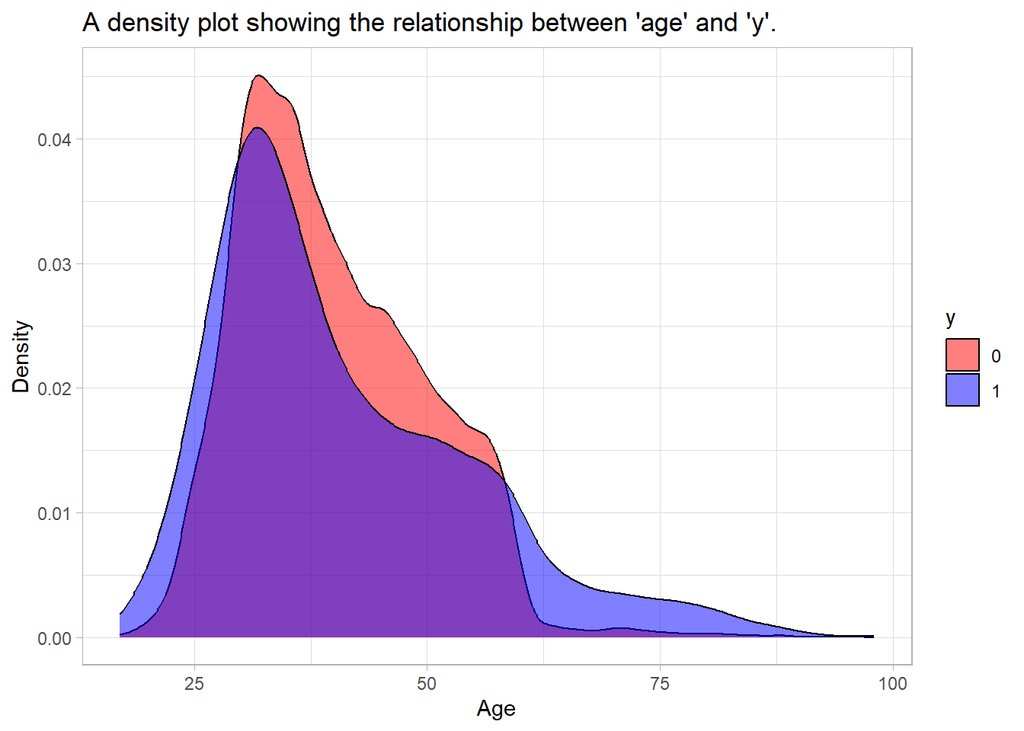

```r
# Density Plot
ggplot(bank.df, aes(x=age, fill = factor(y), group = y)) +
  geom_density(alpha = 0.5) +
  scale_fill_manual(name = "y", values = c("0" = "red", "1" = "blue")) +
  xlab("Age") +
  ylab("Density") +
  labs(title = "A density plot showing the relationship between 'age' and 'y'.") +
  theme_light()
```

#### Top 3 variables in predicting y (Part D)

I think the top three variables that may be important in predicting y are:

- *job*: This seems like a very important variable as being employed would result in more disposable income to put in a term deposit account.
- *pdays*: This variable seems important because if the client hadn’t been contacted in a while they would have less incentive to have a term deposit and thus bank.
- *poutcome*: I would have to imagine that a successful campaign would result in the client having some relation with the bank which is a lot better than clients who don’t and could much more easily translate into them have a term desposit account.

## Task 3 - Model the data

```r
# A) Fitting a series of models on the data
# Logistic regression
logistic.model = glm(y ~ ., data = train.df)
summary(logistic.model)
```

```
##
## Call:
## glm(formula = y ~ ., data = train.df)
##
## Deviance Residuals:
##      Min        1Q    Median        3Q       Max
## -0.80849  -0.10657  -0.05795  -0.01727   1.03746
##
## Coefficients: (1 not defined because of singularities)
##                                Estimate Std. Error t value Pr(>|t|)
## (Intercept)                  -9.972e-01  1.088e+00  -0.916  0.35941
## age                           4.606e-04  1.839e-04   2.504  0.01228 *
## jobblue-collar               -1.790e-02  5.524e-03  -3.241  0.00119 **
## jobentrepreneur              -1.408e-02  8.576e-03  -1.642  0.10063
## jobhousemaid                 -6.257e-04  1.020e-02  -0.061  0.95107
## jobmanagement                -1.292e-02  6.429e-03  -2.010  0.04444 *
## jobretired                    4.631e-02  9.008e-03   5.141 2.75e-07 ***
## jobself-employed             -6.826e-03  8.630e-03  -0.791  0.42895
## jobservices                  -1.708e-02  6.003e-03  -2.845  0.00445 **
## jobstudent                    5.375e-02  1.121e-02   4.796 1.62e-06 ***
## jobtechnician                -8.404e-04  5.312e-03  -0.158  0.87429
## jobunemployed                 2.898e-03  1.002e-02   0.289  0.77236
## jobunknown                   -1.710e-02  1.725e-02  -0.991  0.32169
## maritalmarried                7.152e-03  4.888e-03   1.463  0.14345
## maritalsingle                 1.596e-02  5.628e-03   2.836  0.00457 **
## maritalunknown                3.218e-02  3.447e-02   0.934  0.35051
## educationbasic.6y             2.417e-03  7.984e-03   0.303  0.76206
## educationbasic.9y            -5.704e-03  6.291e-03  -0.907  0.36458
## educationhigh.school          8.689e-04  6.505e-03   0.134  0.89375
## educationprofessional.course  9.387e-03  7.315e-03   1.283  0.19941
## educationuniversity.degree    1.873e-02  6.631e-03   2.824  0.00475 **
## educationunknown              1.357e-02  8.924e-03   1.520  0.12849
## defaultunknown               -2.058e-02  3.903e-03  -5.273 1.35e-07 ***
## housingunknown               -6.255e-03  9.859e-03  -0.634  0.52576
## housingyes                   -9.115e-04  3.028e-03  -0.301  0.76338
## loanunknown                          NA         NA      NA       NA
## loanyes                      -2.199e-03  4.155e-03  -0.529  0.59667
## campaign                     -2.131e-03  5.433e-04  -3.922 8.78e-05 ***
## pdays                        -2.138e-04  2.742e-05  -7.797 6.52e-15 ***
## previous                      1.138e-02  7.217e-03   1.576  0.11493
## poutcomenonexistent           6.990e-02  9.711e-03   7.198 6.22e-13 ***
## poutcomesuccess               1.884e-01  2.704e-02   6.965 3.33e-12 ***
## emp_var_rate                 -4.058e-02  5.505e-03  -7.372 1.72e-13 ***
## cons_price_idx                5.871e-02  6.536e-03   8.984  < 2e-16 ***
## cons_conf_idx                 4.188e-03  5.269e-04   7.949 1.93e-15 ***
## euribor3m                     4.738e-03  6.899e-03   0.687  0.49224
## nr_employed                  -7.955e-04  1.162e-04  -6.847 7.67e-12 ***
## ---
## Signif. codes:  0 '***' 0.001 '**' 0.01 '*' 0.05 '.' 0.1 ' ' 1
##
## (Dispersion parameter for gaussian family taken to be 0.08145561)
##
##     Null deviance: 3694.5  on 37049  degrees of freedom
## Residual deviance: 3015.0  on 37014  degrees of freedom
## AIC: 12271
##
## Number of Fisher Scoring iterations: 2
```

```r
# Ridge regression
ridge_y = train.df$y
ridge_x = train.df %>%
  select(-y) %>%
  data.matrix

ridge.model = glmnet(ridge_x, ridge_y, alpha = 0, verbose = FALSE)
summary(ridge.model) # Couldn't write print(ridge.model) because it displays too much data at once.
```

```
##           Length Class     Mode
## a0         100   -none-    numeric
## beta      1600   dgCMatrix S4
## df         100   -none-    numeric
## dim          2   -none-    numeric
## lambda     100   -none-    numeric
## dev.ratio  100   -none-    numeric
## nulldev      1   -none-    numeric
## npasses      1   -none-    numeric
## jerr         1   -none-    numeric
## offset       1   -none-    logical
## call         5   -none-    call
## nobs         1   -none-    numeric
```

```r
# Random Forest (I did min.node.size = 5 because the response variable y is categorical)
random_forest.model = ranger(y ~ ., data = train.df, classification = TRUE, min.node.size = 5, importance = 'impurity')
random_forest.model
```

```
## Ranger result
##
## Call:
##  ranger(y ~ ., data = train.df, classification = TRUE, min.node.size = 5,      importance = "impurity")
##
## Type:                             Classification
## Number of trees:                  500
## Sample size:                      37050
## Number of independent variables:  16
## Mtry:                             4
## Target node size:                 5
## Variable importance mode:         impurity
## Splitrule:                        gini
## OOB prediction error:             10.27 %
```

```r
# XGBoost
xgboost_y = train.df$y
xgboost_x = train.df %>%
  select(-y) %>%
  data.matrix

xgboost.model = xgboost(data = xgboost_x, label = xgboost_y, nrounds=100, objective="binary:logistic", verbose = FALSE)
summary(xgboost.model) # Couldn't write print(xgboost.model) because it displays too much data at once.
```

```
##                Length Class              Mode
## handle              1 xgb.Booster.handle externalptr
## raw            342393 -none-             raw
## niter               1 -none-             numeric
## evaluation_log      2 data.table         list
## call               14 -none-             call
## params              2 -none-             list
## callbacks           1 -none-             list
## feature_names      16 -none-             character
## nfeatures           1 -none-             numeric
```

```r
# B) Creating a confusion matrix for each model
# Logistic regression
logistic.pred = round(predict(logistic.model, select(test.df, -y), type = "response"))
logistic_confusion_matrix = table(Predicted = logistic.pred, Actual = test.df$y)
logistic_confusion_matrix
```

```
##          Actual
## Predicted    0    1
##         0 3595  379
##         1   48   95
```

```r
# Ridge regression
ridge_test.df = test.df %>%
  select(-y) %>%
  data.matrix

ridge.pred = round(predict(ridge.model, ridge_test.df, type = "response", s = 0.01))
ridge_confusion_matrix = table(Predicted = ridge.pred, Actual = test.df$y)
ridge_confusion_matrix
```

```
##          Actual
## Predicted    0    1
##         0 3594  377
##         1   49   97
```

```r
# Random Forest
random_forest.pred = round(predict(random_forest.model, test.df, type = "response")$predictions)
rf_confusion_matrix = table(Predicted = random_forest.pred, Actual = test.df$y)
rf_confusion_matrix
```

```
##          Actual
## Predicted    0    1
##         0 3560  343
##         1   83  131
```

```r
# XGBoost
xgboost_test.df = test.df %>%
  select(-y) %>%
  data.matrix

xgboost.pred <- round(predict(xgboost.model, xgboost_test.df))
xgboost_confusion_matrix = table(Predicted = xgboost.pred, Actual = test.df$y)
xgboost_confusion_matrix
```

```
##          Actual
## Predicted    0    1
##         0 3558  340
##         1   85  134
```